# Raport

Martyna Majchrzak, Jakub Jung, Paweł Niewiadowski

23 05 2021

## Abstract

## Keywords

# Introduction (Jung)

# Methods

## Explanations (Karol)

### Local

Local explainations allow us to better understand model’s prediction from the level of single observations. This can be usefull when we want to evaluate predictions for particular instances. For example which values have the most importance for the particular observations, or how the change in variables would impact the result. Local explainations combined with professional expertise could somtimes hint towards potential problems with the model in case they contradict eachother.

#### Break Down

In this explaination all observations start from the same base that is the mean prediction for all data. Next steps consist of fixing consequtive variables on values from the observation in question and measuring the change in mean prediction that is now calculeted with some of the values fixed. This shift in mean prediction is interpreted as the impact of this variable’s value on prediction for this observation.

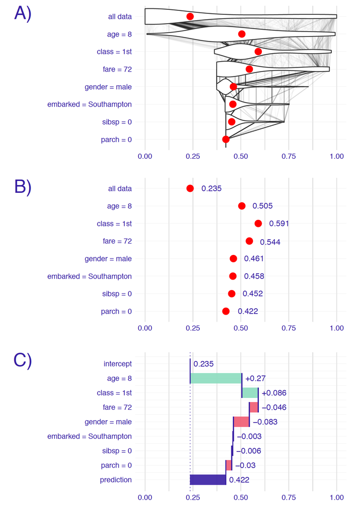

Figure: Panel A shows the distribution and mean prediction with values on the same level and above fixed on values from observation. Then change in mean is calculeted and assigned to corresponding variables.

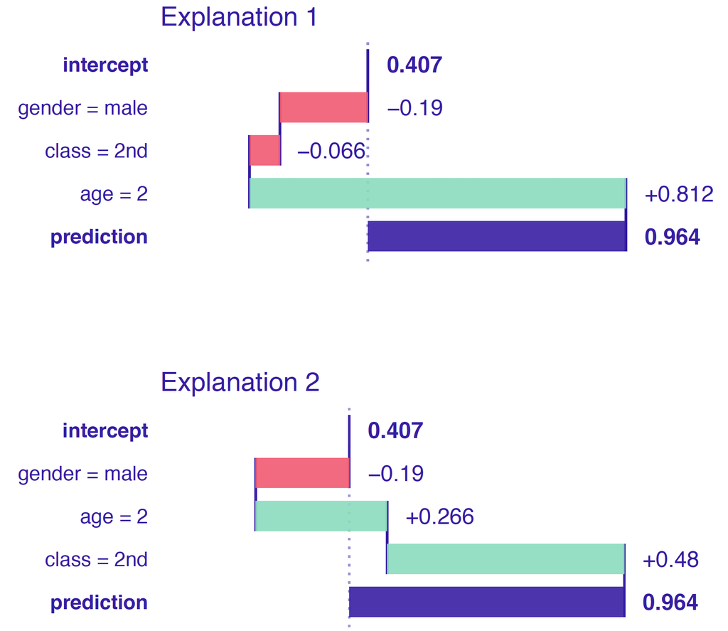

Figure: Variables age and class interact with eachother so the changing order results in different plots

#### Shap

Shap is a direct responce to the biggest problem of Break Down method that is the ordering chosen for explaination could alter the results. Shap takes a nuber of permutation and calculates the average responce of Break Down on theese permutations. More permutations results in more stable explainations.

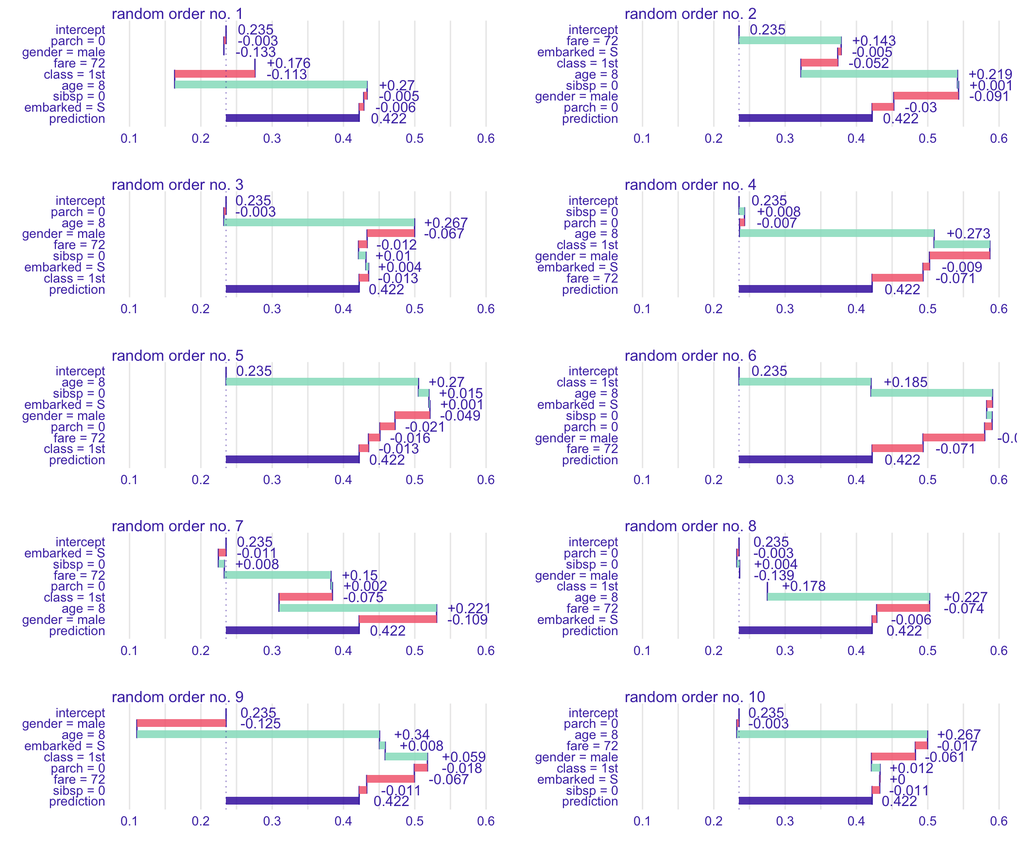

Figure: Different results of Break Down for 10 random variable orders

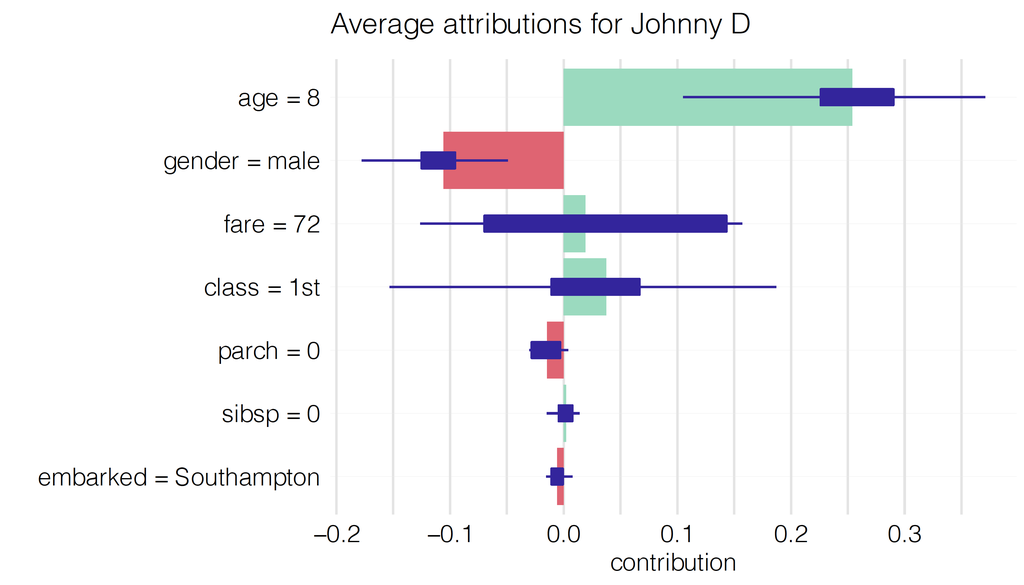

Figure: Shap output. Average impact calculeted with Break Down for 10 permutations

#### Lime

The essence of Lime is to locally approximate the black box model with a glass box one. Then we can use it for local explainations that should yeld results appropiate for the black box. Firstly we generate data “close” to our observation (also called Point of Interest) and make predictions with black box model. Based on those predictions wy try to fit the glass box model that acurately predicts those observations. In result we receive a glassbox model that should behave the same as original model as long as we ramain close to the Point of interest.

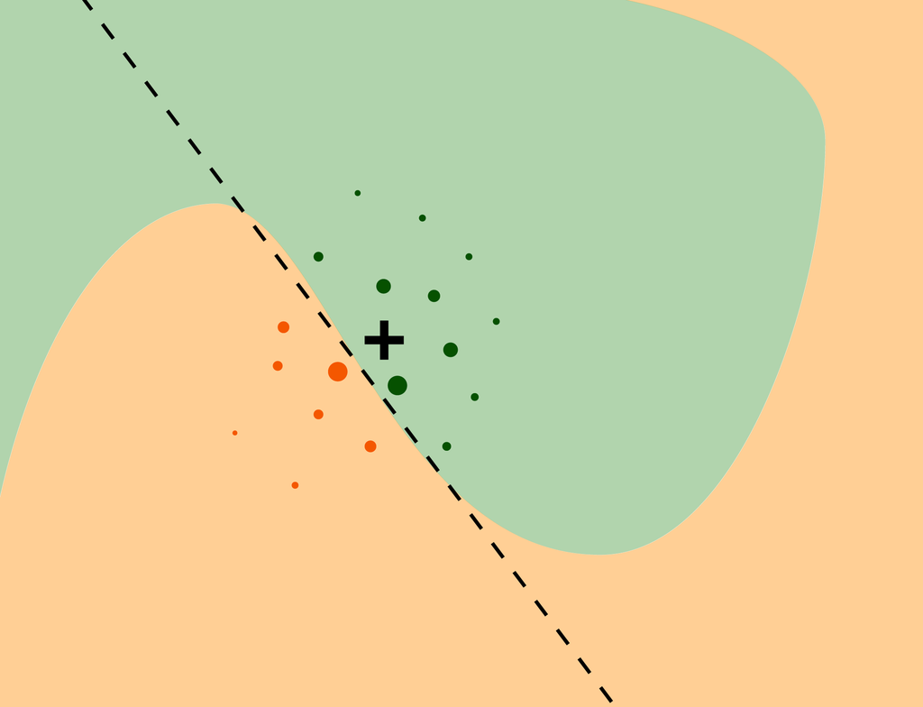

Figure: Colored areas correspond to different prediction for the black box model. Black cross is our Point of Interest and circles are generated data. The line represents our simpler model that approximates original model around Point of Interest

This method is often used for datasets consisting of a large amount of variables. Methods like Break down and Shap come out short in theese situations.

#### Centris Paribus

Centris Paribus is a Latin phrase meaning “all else unchanged”. This acuratly describes what it does. For the certain observation we take values that are interesting to us and observe how the prediction changes as we change values in those columns one at a time. This can yeld interesting conclusions about change in values and it’s impact on predictions.

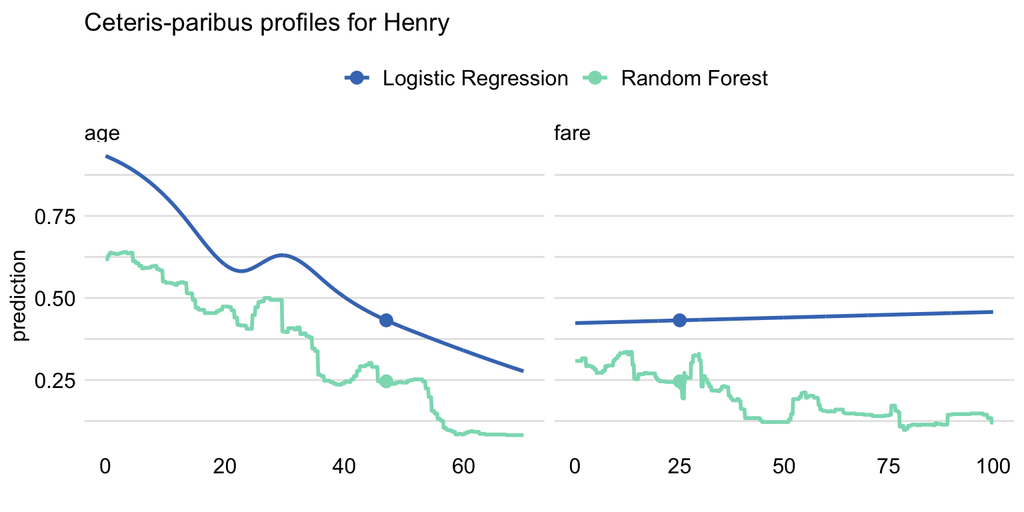

Figure: Shape of lines resebles the nature of the model. Dot shows value and model’s prediction for the observation.

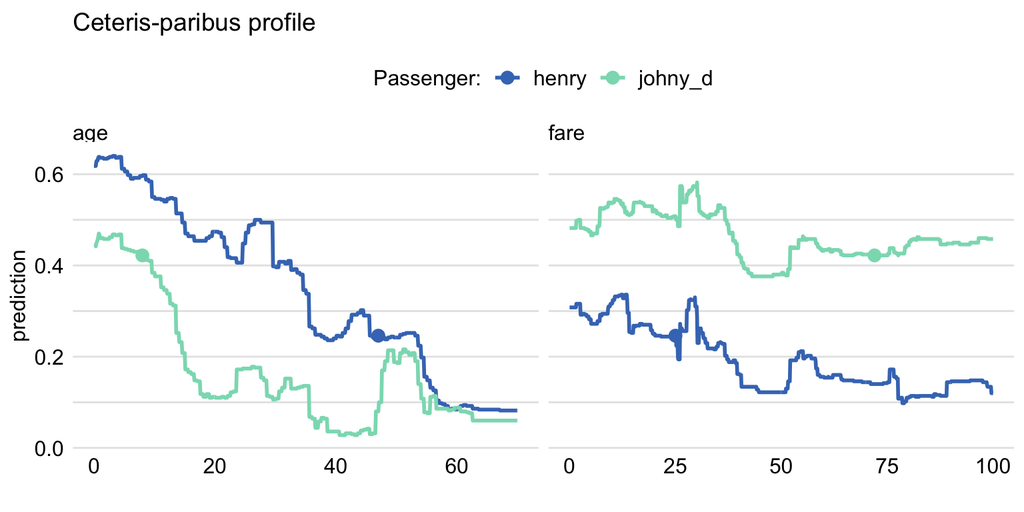

Figure: Centris Paribus shows different importance in variables and their changes for different observations

Centris Paribus is very popular due to it’s simplicity and interpretability. The biggest dravback however is it’s possible unpredictable or missleading results. For example with fixed variable age set to 18 predicting outcome for a significant number of pregnancies doesn’t make sense. It’s also hard to interactions when working with variables separetly.

### Global

#### Partial Dependence

easy to understand

intuitive

can handle interaction in multidimensional cas

struggle with correlated features

#### Acumulated Dependence

Can handle correlated features

Hard to understand, easy to intepretate

# Results

## Model comparison

## Explanations results

### Global

### Local

# Discussion

## Expert opions + comparison

# Conclusion

# References